# 2/12/19 notes

pwilliams

2/12/2019

Using tidyverse, we receive access to a bunch of new commands

# 02/12/19 Notes

## Piping commands using tidyverse packages

**%>%** works similar as a pipe command. Select lets us choose columns (a - in front of column means everything but that column)

```r
# First we call our data frame, then we pipe our dataframe into the next commmand, in this case, the select() command.
selectYC = df %>%
  select(Year_Collected)
head(selectYC)
```

```
##   Year_Collected
## 1           2000
## 2           2000
## 3           2000
## 4           2000
## 5           2000
## 6           2000
```

filter() lets you access all the rows of a specifc command (in this case all the rows with year collected > 2005)

```r
filter1 = df %>%
  filter(Year_Collected > 2005) %>%
  mutate(k2 = DNA_Concentration_Katy^2)
head(filter1)
```

```
##   Year_Collected Extract.Code Date_Collected DNA_Concentration_Katy
## 1           2006       06_A_1     2006-01-17                  0.745
## 2           2006       06_B_1     2006-02-08                  0.605
## 3           2006       06_B_2     2006-02-21                  0.342
## 4           2006       06_C_1     2006-03-07                  0.178
## 5           2006       06_D_1     2006-04-03                  0.411
## 6           2006       06_D_2     2006-04-27                  0.910
##   DNA_Concentration_Ben        Lab       k2
## 1             1.4845609 Downstairs 0.555025
## 2             1.4424582 Downstairs 0.366025
## 3             1.2877089 Downstairs 0.116964
## 4             0.8816887 Downstairs 0.031684
## 5             0.7902102 Downstairs 0.168921
## 6             2.4532713 Downstairs 0.828100
```

The group_by() function allows us to create groups within columns. When paired with summarise it becomes **DEADLY**

```r
gbsum1 = df %>%
  group_by(Year_Collected) %>%
  summarise(N = n(), MeanBen = mean(DNA_Concentration_Ben), SDBen = sd(DNA_Concentration_Ben))
head(gbsum1)
```

```
## # A tibble: 6 x 4
##   Year_Collected     N MeanBen SDBen
##            <int> <int>   <dbl> <dbl>
## 1           2000    17   0.484 0.391
## 2           2001    22   0.543 0.406
## 3           2002    24   0.565 0.323
## 4           2003    24   0.438 0.285
## 5           2004    17   0.731 0.406
## 6           2005    16   1.28  0.510
```

```r
#This grouped our Year_Collected column nicely
```

We practiced subsetting large data frames using tidyr commands with the Iris data set

```r
df2 = df %>%
  group_by(Species) %>%
  summarise(N = n(), SLMEAN = mean(Sepal.Length), SDsl = sd(Sepal.Length), MINsl = min(Sepal.Length), MAXsl = max(Sepal.Length)) %>%
  as.data.frame() # The as.data.frame() function needed to be added because, without it, the dataframe is stored as a tibble, which makes it difficult to work with in some programs or on some devices

#Check our new class of df2
class(df2)
```

```
## [1] "data.frame"
```

```r
df2
```

```
##      Species  N SLMEAN      SDsl MINsl MAXsl
## 1     setosa 50  5.006 0.3524897   4.3   5.8
## 2 versicolor 50  5.936 0.5161711   4.9   7.0
## 3  virginica 50  6.588 0.6358796   4.9   7.9
```

Next we used how to search within dataframes (specifically column and row names) using the select() function and its arguments.

```r
#Starts_with selects column names that start with a provided search factor
startwithS = df %>%
  select(starts_with("S"))
head(startwithS)
```

```
##   Sepal.Length Sepal.Width Species
## 1          5.1         3.5  setosa
## 2          4.9         3.0  setosa
## 3          4.7         3.2  setosa
## 4          4.6         3.1  setosa
## 5          5.0         3.6  setosa
## 6          5.4         3.9  setosa
```

```r
#To explore data sets when column names are unknown:
pickone = df%>%
  select(one_of(c("Petal.Length", "Sepal.Roundness")))
head(pickone)
```

```
##   Petal.Length
## 1          1.4
## 2          1.4
## 3          1.3
## 4          1.5
## 5          1.4
## 6          1.7
```

Here are some common commands for tidying and manipulating data in tidyverse: + arrange() + filter() + select() + mutate() + group_by()

## Tidying data sets using tidyr

In tidy data: + Every row = observation + Every column = single variable + Element = Value

Here are two data frames

```
##   CustomerId Product
## 1          1 Toaster
## 2          2 Toaster
## 3          3 Toaster
## 4          4   Radio
## 5          5   Radio
## 6          6   Radio
```

```
##   CustomerId   State
## 1          2 Alabama
## 2          4 Alabama
## 3          6    Ohio
```

Join them together using the commands below:

```r
full_join(df1,df2, by="CustomerId")
```

```
##   CustomerId Product   State
## 1          1 Toaster    <NA>
## 2          2 Toaster Alabama
## 3          3 Toaster    <NA>
## 4          4   Radio Alabama
## 5          5   Radio    <NA>
## 6          6   Radio    Ohio
```

```r
#Combines everything from both dfs
left_join(df1,df2, by="CustomerId")
```

```
##   CustomerId Product   State
## 1          1 Toaster    <NA>
## 2          2 Toaster Alabama
## 3          3 Toaster    <NA>
## 4          4   Radio Alabama
## 5          5   Radio    <NA>
## 6          6   Radio    Ohio
```

```r
#combines everything from the by argument in left df with matching by arguments in right df
right_join(df1,df2, by="CustomerId")
```

```
##   CustomerId Product   State
## 1          2 Toaster Alabama
## 2          4   Radio Alabama
## 3          6   Radio    Ohio
```

```r
##combines everything from the by argument in left df with matching by arguments in right df
inner_join(df1,df2, by="CustomerId")
```

```
##   CustomerId Product   State
## 1          2 Toaster Alabama
## 2          4   Radio Alabama
## 3          6   Radio    Ohio
```

```r
semi_join(df1,df2, by="CustomerId")
```

```
##   CustomerId Product
## 1          2 Toaster
## 2          4   Radio
## 3          6   Radio
```

```r
anti_join(df1,df2, by="CustomerId")
```

```
##   CustomerId Product
## 1          1 Toaster
## 2          3 Toaster
## 3          5   Radio
```

What is the difference between these different functions?

## Converting wide data sets into long ones using the gather() function.

```r
head(utah)
```

```
##             County Pop_2010 Religious Non.Religious Assemblies.of.God
## 1    Beaver County     6629 0.7762889    0.22371398       0.000000000
## 2 Box Elder County    49975 0.9029500    0.09704852       0.002398889
## 3     Cache County   112656 0.8774600    0.12254119       0.002620000
## 4    Carbon County    21403 0.7994189    0.20057936       0.001168889
## 5   Daggett County     1059 0.6562789    0.34372049       0.000000000
## 6     Davis County   306479 0.8237100    0.17628940       0.010820000
##   Episcopal.Church Pentecostal.Church.of.God Greek.Orthodox       LDS
## 1          0.00000               0.000000000        0.00000 0.7489800
## 2          0.00170               0.002758889        0.00000 0.8137689
## 3          0.00283               0.003128889        0.00000 0.8225489
## 4          0.00598               0.000000000        0.01308 0.5310900
## 5          0.00000               0.000000000        0.00000 0.6562789
## 6          0.00093               0.000660000        0.00000 0.7465900
##   Southern.Baptist.Convention United.Methodist.Church Buddhism.Mahayana
## 1                     0.00241             0.000000000      0.0000000000
## 2                     0.00394             0.003318889      0.0250125063
## 3                     0.00383             0.000000000      0.0000000000
## 4                     0.00841             0.005190000      0.0000000000
## 5                     0.00000             0.000000000      0.0000000000
## 6                     0.00724             0.000000000      0.0003328124
##     Catholic Evangelical  Muslim Non.Denominational Orthodox
## 1 0.02292889 0.004218889 0.00000            0.00000  0.00000
## 2 0.04017889 0.016148889 0.00000            0.00540  0.00000
## 3 0.02935889 0.014168889 0.00273            0.00372  0.00000
## 4 0.19113889 0.046820000 0.00000            0.00832  0.01308
## 5 0.00000000 0.000000000 0.00000            0.00000  0.00000
## 6 0.04171000 0.025870000 0.00016            0.00302  0.00000
```

This is an example of a wide data set. Each variable that consists of a relgion should be condensed into two columns: one titled Religion, and the other titled Proportion. This can be done using the gather() command:

```r
utah.long = gather(utah, key = "Religion", value = "Proportion", -c(1:4))

utah.long$County <- factor(str_remove(utah.long$County, " County"))
# We simply removed the word County from every element within the County variable
```

Now we can plot this data set using ggplot (which we could not do before)

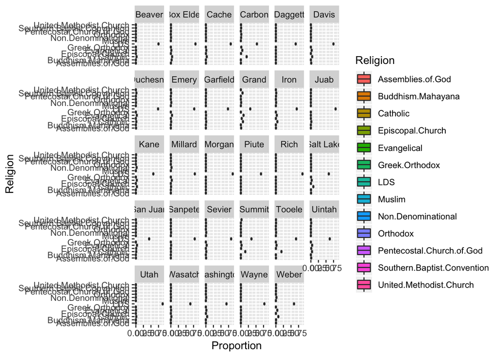

```r
ggplot(utah.long, aes(x = Religion, y = Proportion, fill = Religion)) +
  geom_boxplot() + coord_flip() +facet_wrap(utah.long$County)
```

Hmmm, it looks like the observation “LDS” is having a large affect on the rest of our data. Lets get rid of that variable just to see what the other data looks like.

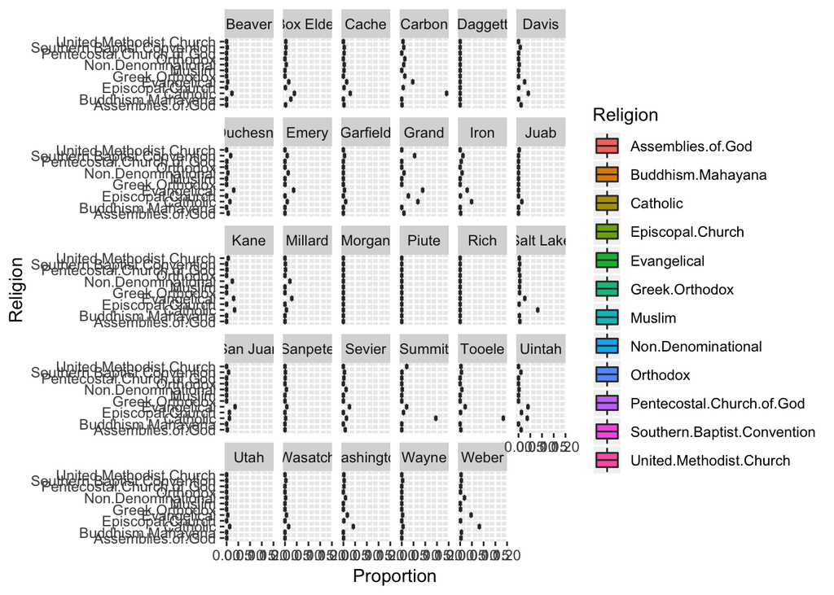

```r
utah.long %>%
  filter(Religion != "LDS") %>%
  ggplot(aes(x = Religion, y = Proportion, fill = Religion)) +
  geom_boxplot() + coord_flip() + facet_wrap(~County)
```